# Кластерный анализ. Многомерное шкалирование

© Alexander Doynikov,dep. CS, MSU

October 19, 2021

# Кластерный анализ

## Меры сходства

Для проведения классификации необходимо ввести понятия сходства объектов В кластерном анализе для количественного оценки сходства вводится понятие метрики. Наиболее популярные меры расстояния между объектами

1.Евклидово расстояние
$$d_{ij}=\sqrt{\sum_{k=1}^{m}(x_{ik}-x_{jk})^2}$$
2.Взвешенное Евклидово расстояние
$$d_{ij}=\sqrt{\sum_{k=1}^{m}w_k(x_{ik}-x_{jk})^2}$$
3.Расстояние city-block
$$d_{ij}=\sum_{k=1}^{m}|x_{ik}-x_{jk}|$$
4.Расстояние Минковского
$$d_{ij}=(\sum_{k=1}^{m}|x_{ik}-x_{jk}|^p)^{1/p}$$
5.Расстояние Махалонобиса
$$d_{ij}=(X_i-X_j)'S^{-1}(X_i-X_j)$$
где $S$-ковариационная матрица

Оценки расстояний сильно зависят от абсолютных значений, поэтому полезно провести процедуру нормировки.

Наиболее часто используемые нормировки:
$$z_{ij}=(x_{ij}-x_{j})/(σ_{j})$$
$$z_{ij}=x_{ij}/x_{max,j}$$
$$z_{ij}=x_{ij}/x_{min,j}$$
В финансовых данных чаще всего переходят к доходностям
$$r_{t,j}=ln\frac{x_{t,j}}{x_{t-1,j}}$$
или
$$r_{t,j}=\frac{x_{t,j}}{x_{t-1,j}}-1$$

## Иерархический кластерный анализ

Сущность заключается в том, что каждый объект выборки полагается кластером,процесс объединения кластеров проводится последовательно на основании матрицы расстояний. Т.е. объединяются наиболее близкие объекты. До тех пор пока все они не будут объединены в один кластер. Процесс отображается на так называемой дендрограмме, где отображается расстояние на котором произошло объединение. Если матрица расстояний первоначально имела размерность $m*m$, то процесс закончится за $m-1$ шагов.

## Методы объединения

### Метод среднего

Для решения вопроса о включении нового объекта в существующий кластер вычисляется среднее значение меры сходства. Объединяются кластеры с наименьшими мерами сходства. Для примеры рассмотрим акции Российских компаний .

```r
StocsData <- read.csv(file = "./moex.csv",header = TRUE)
head(StocsData)
```

```
##    X.DATE. Gazprom     VTB Gazpromneft Lukoil megafon Rostelecom Sberbank
## 1 09/01/15  144.50 0.06728       146.5 2455.0     805      79.62    73.14
## 2 09/02/15  142.57 0.06695       147.4 2440.0     806      79.46    72.90
## 3 09/03/15  145.30 0.06785       148.1 2503.0     810      80.39    74.15
## 4 09/04/15  142.80 0.06750       147.9 2458.0     809      80.30    73.96
## 5 09/07/15  141.67 0.06830       147.7 2446.7     810      79.60    73.81
## 6 09/08/15  143.21 0.06976       148.6 2462.1     809      80.05    74.90
##   Surgutngaz tatneft
## 1      33.75  310.00
## 2      33.60  305.05
## 3      34.03  309.00
## 4      34.10  304.90
## 5      34.08  304.95
## 6      34.45  307.10
```

```r
tail(StocsData)
```

```
##      X.DATE. Gazprom     VTB Gazpromneft Lukoil megafon Rostelecom Sberbank
## 805 11/06/18  156.00 0.03615       386.0 5055.0   608.5      70.62   197.80
## 806 11/07/18  157.85 0.03819       386.0 5174.5   596.5      70.60   201.90
## 807 11/08/18  157.51 0.03803       389.5 5160.0   585.0      70.36   202.89
## 808 11/09/18  153.19 0.03757       377.0 5094.5   586.0      70.30   195.75
## 809 11/12/18  150.89 0.03818       377.0 5129.0   583.0      70.72   196.82
## 810 11/13/18  150.70 0.03897       377.6 5007.0   588.3      70.97   198.78
##     Surgutngaz tatneft
## 805     27.030   802.2
## 806     27.305   814.1
## 807     27.225   819.2
## 808     27.365   813.4
## 809     26.940   812.3
## 810     27.175   800.9
```

```r
Stocs <- StocsData[,-1]
head(Stocs)
```

```
##   Gazprom     VTB Gazpromneft Lukoil megafon Rostelecom Sberbank Surgutngaz
## 1  144.50 0.06728       146.5 2455.0     805      79.62    73.14      33.75
## 2  142.57 0.06695       147.4 2440.0     806      79.46    72.90      33.60
## 3  145.30 0.06785       148.1 2503.0     810      80.39    74.15      34.03
## 4  142.80 0.06750       147.9 2458.0     809      80.30    73.96      34.10
## 5  141.67 0.06830       147.7 2446.7     810      79.60    73.81      34.08
## 6  143.21 0.06976       148.6 2462.1     809      80.05    74.90      34.45
##   tatneft
## 1  310.00
## 2  305.05
## 3  309.00
## 4  304.90
## 5  304.95
## 6  307.10
```

Перейдем к доходностям
$$r_{t,i}= S_{t,i}/S_{t-1,i}$$

```r
n <-dim(Stocs)[1]-1
m <-dim(Stocs)[2]
rates <- matrix(NA,nrow = 0,ncol = m)
colnames(rates)<-colnames(Stocs)
for (i in 1:n)
{
v <- Stocs[i+1,]/Stocs[i,] -1
rates <- rbind(rates,v)
}
head(rates)
```

```
##        Gazprom          VTB  Gazpromneft       Lukoil      megafon   Rostelecom
## 2 -0.013356401 -0.004904875  0.006143345 -0.006109980  0.001242236 -0.002009545
## 3  0.019148488  0.013442868  0.004748982  0.025819672  0.004962779  0.011704002
## 4 -0.017205781 -0.005158438 -0.001350439 -0.017978426 -0.001234568 -0.001119542
## 5 -0.007913165  0.011851852 -0.001352265 -0.004597234  0.001236094 -0.008717310
## 6  0.010870332  0.021376281  0.006093433  0.006294192 -0.001234568  0.005653266
## 7  0.007052580 -0.008314220  0.009421265  0.015880752  0.001236094  0.011867583
##       Sberbank    Surgutngaz       tatneft
## 2 -0.003281378 -0.0044444444 -0.0159677419
## 3  0.017146776  0.0127976190  0.0129486969
## 4 -0.002562374  0.0020570085 -0.0132686084
## 5 -0.002028123 -0.0005865103  0.0001639882
## 6  0.014767647  0.0108568075  0.0070503361
## 7 -0.003337784  0.0065312046  0.0045587756
```

```r
rates <- as.matrix(rates)
```

Считаем эвклидово расстояние

```r
distRates<- dist(t(rates),method = "euclidean")
distRates
```

```
##               Gazprom       VTB Gazpromneft    Lukoil   megafon Rostelecom
## VTB         0.4628780
## Gazpromneft 0.4407841 0.5006583
## Lukoil      0.3876327 0.4787032   0.4639421
## megafon     0.5947979 0.6394161   0.5943492 0.6370906
## Rostelecom  0.4222404 0.4862839   0.4570817 0.4839765 0.5862150
## Sberbank    0.4846575 0.5301901   0.5430102 0.5171760 0.6854413  0.5625531
## Surgutngaz  0.4139020 0.4871955   0.4712757 0.4520217 0.6155105  0.4353083
## tatneft     0.5015271 0.5843615   0.5585606 0.4809305 0.7283856  0.5607695
##              Sberbank Surgutngaz
## VTB
## Gazpromneft
## Lukoil
## megafon
## Rostelecom
## Sberbank
## Surgutngaz  0.5633017
## tatneft     0.6221946  0.5372940
```

И проводим иерархическую кластеризацию

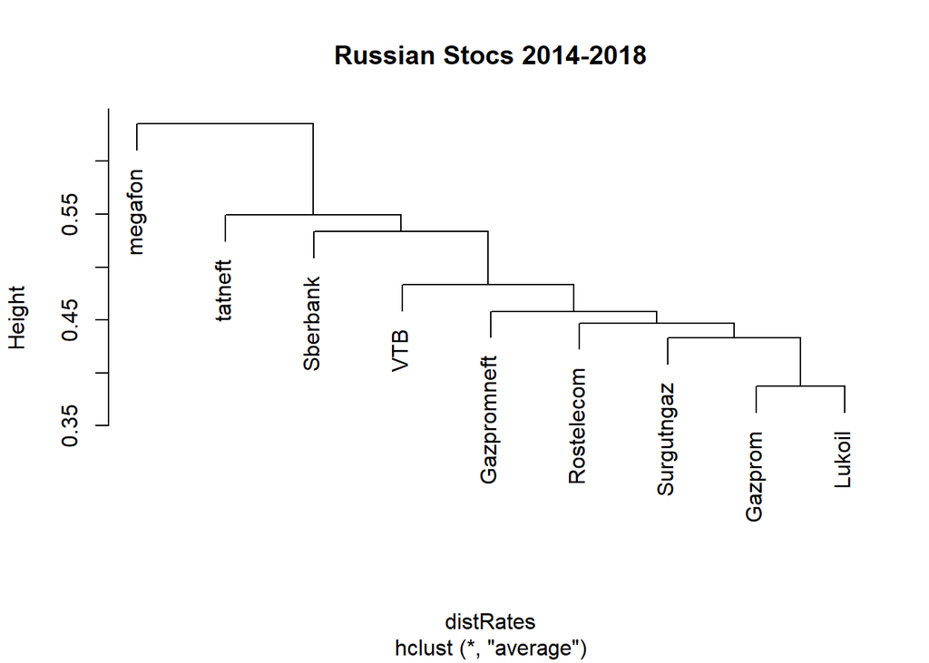

```r
hRates <- hclust(distRates, method = "average")
plot(hRates,main = "Russian Stocs 2014-2018")
```

Cравним эту же кластеризацию с данными за 2018-2021 год.

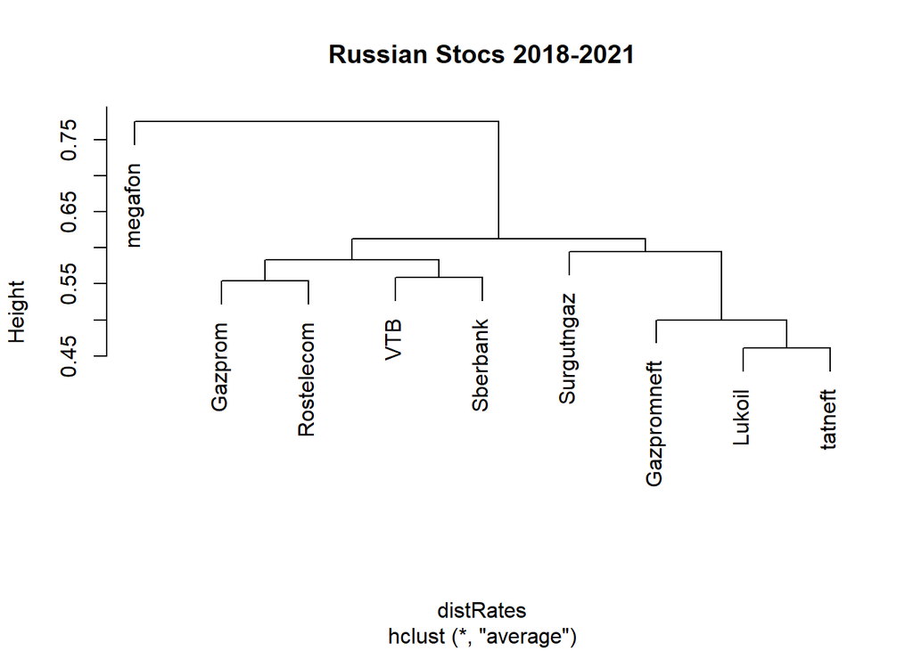

### Метод медианы

Аналогично только вместо среднего берется медиана.

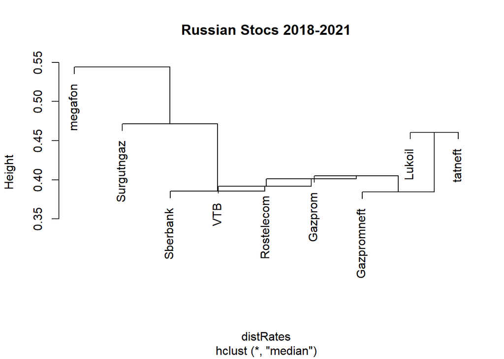

```r
hRates <- hclust(distRates, method = "median")
plot(hRates,main = "Russian Stocs 2018-2021")
```

### Метод ближайшего соседа

Объединяются два кластера с ближашими объектами.

### Метод дальнего соседа

Объединяются два кластера с дальними объектами.

### Метод Ward

Данный метод предполагает, что на первом шаге каждый кластер состоит из одного объекта. Первоначально объединяются ближайшие и вычисляется стандартное отклонение близости объектов одного кластера. В дальнейшем объединяются те кластеры, которые дают наименьшее приращение стандартного отклонения. Таким образом образуются кластеры с наименьшей внутрикластерной дисперсией

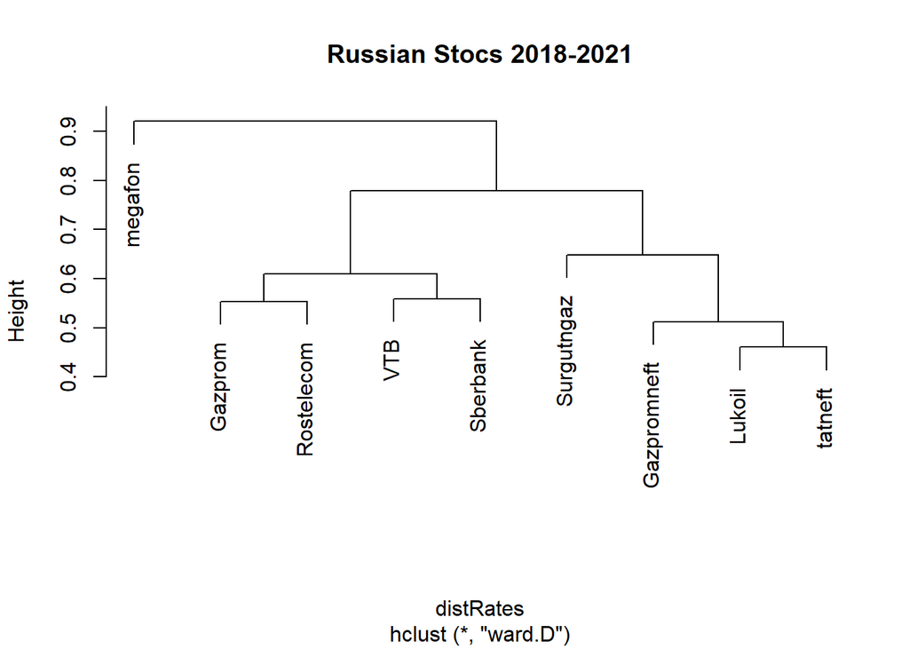

```r
hRates <- hclust(distRates, method = "ward.D")
plot(hRates,main = "Russian Stocs 2018-2021")
```

## Метод k-средних

Кроме иерархической кластеризации существует многочисленная группа итеративных методов. Сущность их заключается в том, что процесс классификации начинается с задания некоторых начальных условий. Исторически первым стал метод k-средних. В этих методах нет необходимости хранить всю матрицу расстояний. Пусть имеется n наблюдений с признаками $X_1,...Х_p$, которые необходимо разбить на $k$ кластеров. Для начала случайно задаются $k$ точек. Каждой точке присваиваевается порядковый номер это и будет номером кластера. На первом шаге из оставшихся $n-k$ точек точка $X_i$ c координатами $x_{i,1},...,x_{i,p}$ и определяется к какому номеру она ближе в смысле выбранного расстояния $d_{i,l} ,l = 1,...,k$. Эталон заменяется новым пересчитанным с учетом новой точки и вес его увеличивается (количество точек в кластере). Далее этот алгоритм повторяется для всех $n-k$ точек. На этом первый этап заканчивается. Затем опять все точки $X_1,...,X_n$ опять относят к одному из кластеров и сравнивают разбиение с разбиением на прошлом шаге.Если оно не изменилось, то алгоритм заканчивает В противном случае все повторяется. Имеется две модификации метода. Первая состоит в пересчете центра тяжести кластера после каждого изменения состава, при второй пересчет центра происходит после просмотра всех объектов.

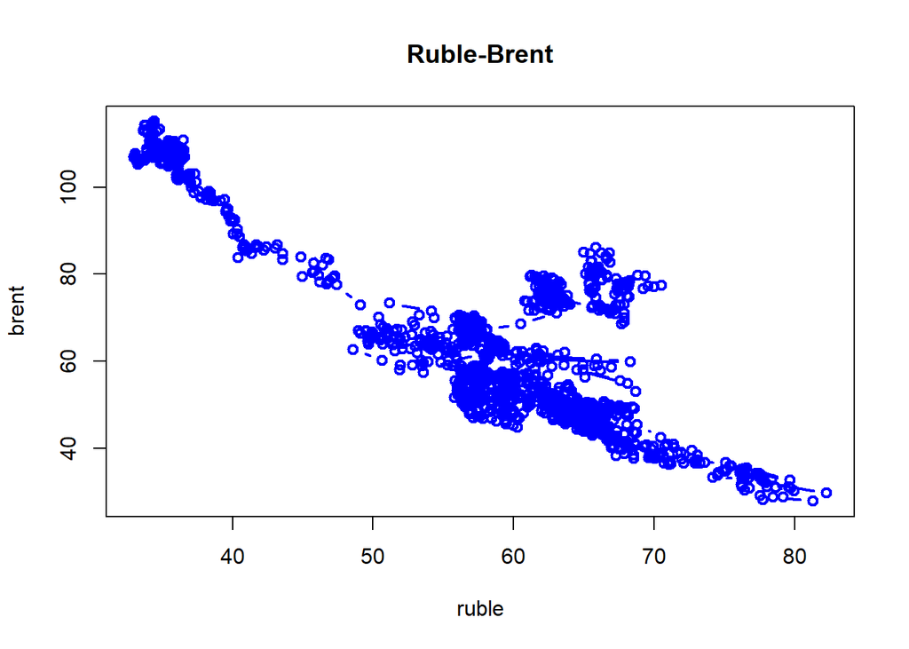

```r
Path = "./"
Ruble <- read.csv("./RubleBrent.csv")
X <- cbind(Ruble[,2],Ruble[,3])
dd <- dist(X,method = "euclidean",diag = FALSE)
plot(Ruble[,2],Ruble[,3],xlab = "ruble",ylab= "brent" ,main = "Ruble-Brent",type = "b",pch = 21,col = "blue",lwd = 2)
```

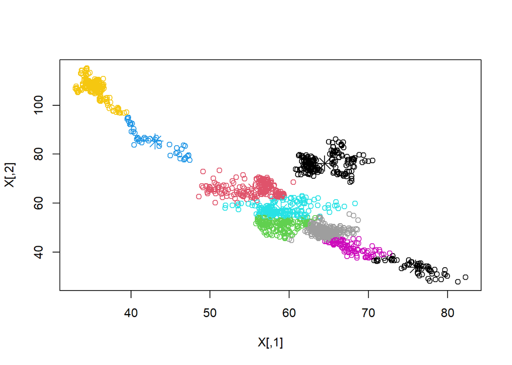

```r
cl <- kmeans(X, 9)
plot(X, col = cl$cluster)
points(cl$centers, col = 1:9, pch = 8, cex = 2)
```

```r
cl$centers
```

```
##       [,1]      [,2]
## 1 64.48619  76.20765
## 2 55.52562  65.67380
## 3 58.75770  51.08601
## 4 43.07335  85.29356
## 5 58.97791  57.29964
## 6 67.60616  42.12188
## 7 35.40933 107.03468
## 8 64.55909  48.58027
## 9 75.96516  33.74279
```

```r
cl
```

```
## K-means clustering with 9 clusters of sizes 187, 208, 183, 45, 221, 96, 220, 262, 61
##
## Cluster means:
##       [,1]      [,2]
## 1 64.48619  76.20765
## 2 55.52562  65.67380
## 3 58.75770  51.08601
## 4 43.07335  85.29356
## 5 58.97791  57.29964
## 6 67.60616  42.12188
## 7 35.40933 107.03468
## 8 64.55909  48.58027
## 9 75.96516  33.74279
##
## Clustering vector:
```

[output cut: 51 more lines]

Добавим 2018-2021

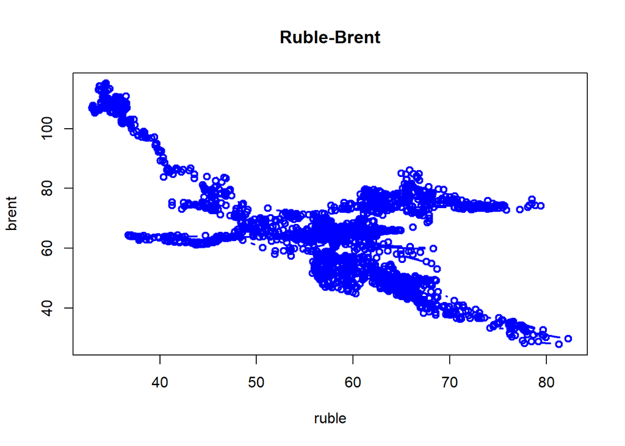

```r
Ruble1 <- read.csv("./RubleBrent2021.csv")
X1 <- cbind(Ruble1[,2],Ruble1[,3])
dd1 <- dist(X1,method = "euclidean",diag = FALSE)
plot(Ruble1[,2],Ruble1[,3],xlab = "ruble",ylab= "brent" ,main = "Ruble-Brent",type = "b",pch = 21,col = "blue",lwd = 2)
```

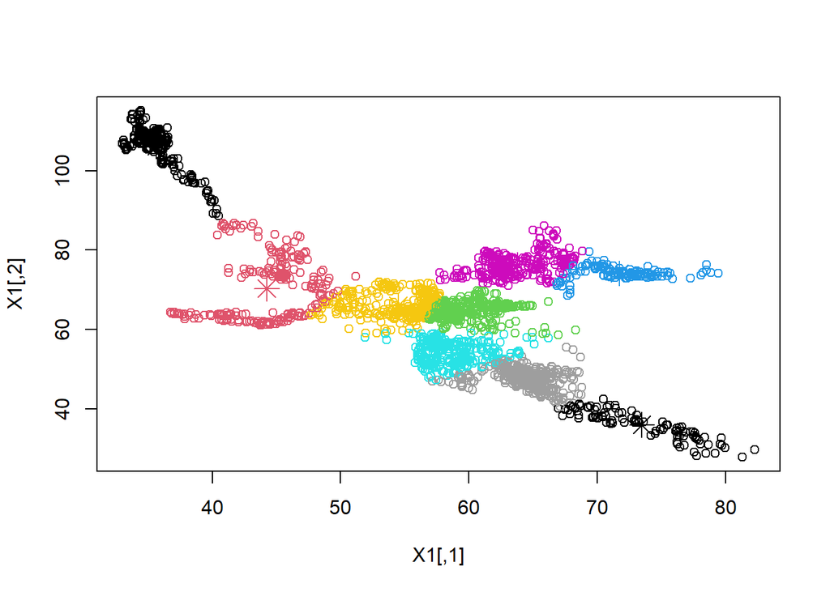

```r
cl1 <- kmeans(X1, 9)
plot(X1, col = cl1$cluster)
points(cl1$centers, col = 1:9, pch = 8, cex = 2)
```

```r
cl1$centers
```

```
##       [,1]      [,2]
## 1 35.64585 106.25802
## 2 44.24629  70.29011
## 3 60.13084  64.73452
## 4 71.73732  74.13477
## 5 58.64297  54.13785
## 6 63.79375  76.29145
## 7 54.48278  66.04203
## 8 64.46959  47.65872
## 9 73.46750  35.97343
```

```r
cl1
```

```
## K-means clustering with 9 clusters of sizes 232, 217, 335, 122, 330, 270, 307, 345, 99
##
## Cluster means:
##       [,1]      [,2]
## 1 35.64585 106.25802
## 2 44.24629  70.29011
## 3 60.13084  64.73452
## 4 71.73732  74.13477
## 5 58.64297  54.13785
## 6 63.79375  76.29145
## 7 54.48278  66.04203
## 8 64.46959  47.65872
## 9 73.46750  35.97343
##
## Clustering vector:
```

[output cut: 71 more lines]

## Cравнение моделей кластризации

### Байесовский информационный критерий (BIC)

Байесовский информационный критерий (Bayesian information criterion, BIC, иногда - Schwarz Criterion) - критерий выбора модели из класса параметризованных моделей, зависящих от разного числа параметров. Для оценивания модели обычно используется метод нахождения максимума функции правдоподобия, значение которого можно увеличить добавлением дополнительных параметров. Однако, это может вызвать переобучение. Байесовский критерий устраняет проблему переобучения, штрафуя увеличение числа параметров модели. Тесно связан с критерием Акаике, но в случае байесовского критерия увеличение параметров штрафуется строже.

$X = \{x_i\}^{n}_{i=1}$ - наблюдаемая часть выборки, где каждый объект характеризуется набором параметров $x_i=(x_{i_1},...,x_{i_k})$. $L$ - максимальное значение функции правдоподобия наблюдаемой выборки с известным числом параметров. Тогда байесовский информационный критерий определяется формулой:
$$BIC = -2\ln(L)+k\ln(n)$$
Таким образом байесовский критерий является аналогом критерия Акаике с более строгой функцией штрафа (функция штрафа зависит также от размерности модели).

```r
library(mclust)
```

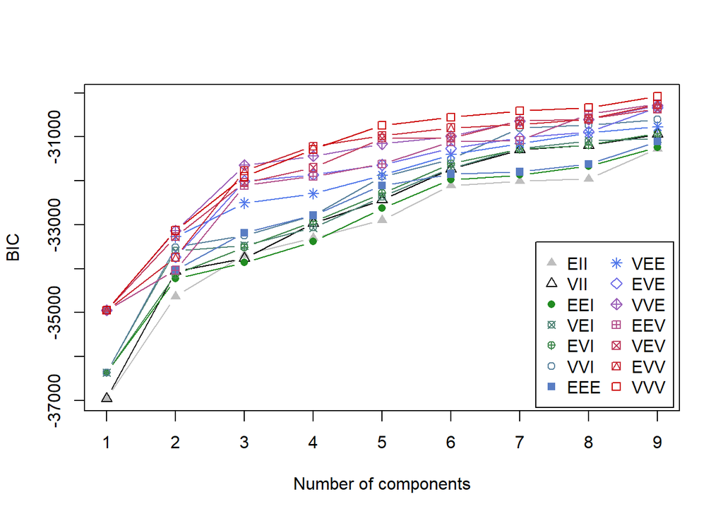

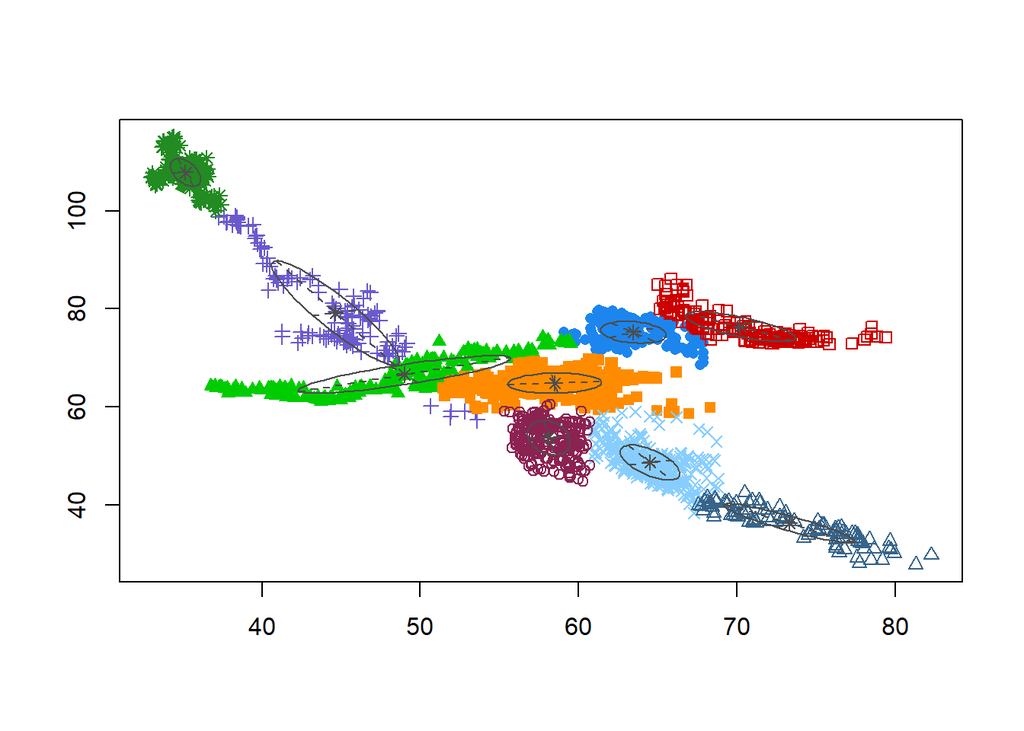

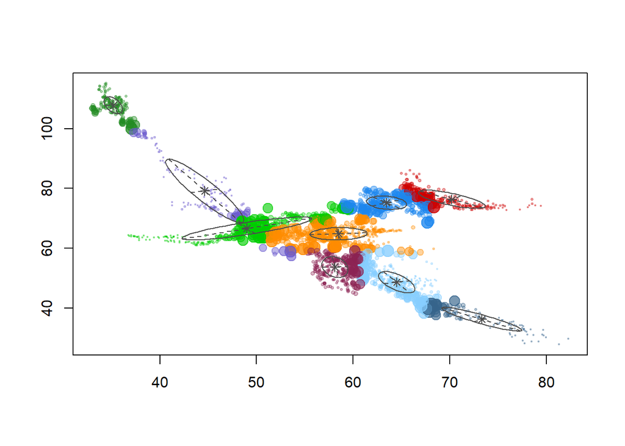

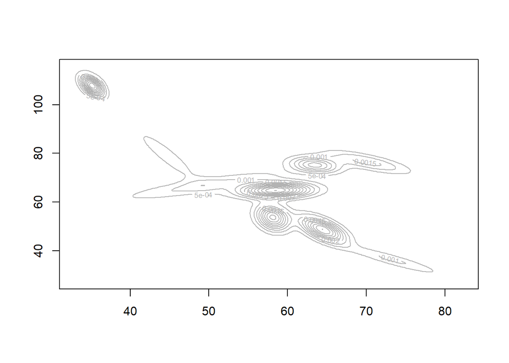

```r
fit <- Mclust(X1)
plot(fit) # plot results
```

```r
table(fit$classification)
```

```
##
##   1   2   3   4   5   6   7   8   9
## 212 170 228 141 528 375 302 204  97
```

```r
summary(fit) # display the best model
```

```
## ----------------------------------------------------
## Gaussian finite mixture model fitted by EM algorithm
## ----------------------------------------------------
##
## Mclust VVV (ellipsoidal, varying volume, shape, and orientation) model with 9
## components:
##
##  log-likelihood    n df       BIC      ICL
##       -14836.47 2257 53 -30082.19 -30376.9
##
## Clustering table:
##   1   2   3   4   5   6   7   8   9
## 212 170 228 141 528 375 302 204  97
```

```r
library(fpc)
set.seed(20000)
  options(digits=3)
  face <- rFace(200,dMoNo=2,dNoEy=0,p=2)
  dface <- dist(face)

  complete3 <- cutree(hclust(dface),3)
  cluster.stats(dface,complete3,            alt.clustering=as.integer(attr(face,"grouping")))
```

```
## $n
## [1] 200
##
## $cluster.number
## [1] 3
##
## $cluster.size
## [1] 136  60   4
##
## $min.cluster.size
## [1] 4
##
## $noisen
## [1] 0
##
## $diameter
## [1] 10.80  5.76  9.00
##
## $average.distance
## [1] 3.03 2.21 7.05
##
## $median.distance
## [1] 2.84 1.48 8.32
##
## $separation
## [1] 5.87 5.87 7.22
##
## $average.toother
## [1] 13.8 13.0 20.8
##
## $separation.matrix
##       [,1] [,2]  [,3]
## [1,]  0.00 5.87 14.98
## [2,]  5.87 0.00  7.22
## [3,] 14.98 7.22  0.00
##
## $ave.between.matrix
##      [,1] [,2] [,3]
## [1,]  0.0 13.1 24.5
## [2,] 13.1  0.0 12.2
```

[output cut: 53 more lines]

```
##
## $cwidegap
## [1] 1.81 1.21 8.32
##
## $widestgap
## [1] 8.32
##
## $sindex
## [1] 6.19
##
## $corrected.rand
## [1] 0.345
##
## $vi
## [1] 0.97
```

```r
 dd <- dist(X1,method = "euclidean",diag = FALSE)
  #cluster.stats(d = dd,clustering= c(3,5))
```

## Классификация

Алгоритм k-NN является одним из самых простых из всех алгоритмов машинного обучения. Многих также может удивить то, что k-NN является одним из 10 лучших алгоритмов интеллектуального анализа данных.

Алгоритм k-ближайших соседей (или для краткости k-NN) - это непараметрический метод, используемый для классификации и регрессии. В обоих случаях входные точки состоят из k ближайших обучающих примеров в пространстве признаков.

Непараметрический означает, что он не делает никаких предположений о базовом распределении данных. Поскольку точки находятся в пространстве признаков, они имеют понятие расстояния. Это не обязательно должно быть евклидово расстояние, хотя оно обычно используется. Каждый из обучающих данных состоит из набора векторов и метки класса, связанной с каждым вектором. В простейшем случае это будет либо +, либо - (для положительных или отрицательных классов). Но k-NN может одинаково хорошо работать с произвольным количеством классов.

Важным параметром метода является число k, которое определяет, сколько соседей (где соседи определяются на основе метрики расстояния) влияют на классификацию. С заданным значением k мы можем определить границы каждого класса. Для любой фиксированной точки x мы можем вычислить, насколько близко каждое наблюдение $X_i$ находится к $x$, используя евклидово расстояние. Это ранжирует данные по тому, насколько они близки к $x$.

Эффективность алгоритма k-NN во многом зависит от значения $k$, т.е. от выбора числа ближайших соседей. Выбор оптимального значения $k$ лучше всего производить, предварительно изучив данные. В общем, большое значение $k$ является более точным, поскольку оно снижает общий шум, но нет никаких гарантий. Перекрестная проверка - это еще один способ ретроспективно определить хорошее значение $k$ с использованием независимого набора данных для проверки значения $k$. Исторически оптимальное значение k для большинства наборов данных составляло от 3 до 10.

k-NN делает прогнозы, используя набор обучающих данных напрямую. Прогнозы для нового экземпляра x делаются путем поиска по всему обучающему набору k наиболее похожих экземпляров (соседей) и суммирования выходной переменной для этих k экземпляров. Для регрессии это может быть средняя выходная переменная, при классификации это может быть значение класса режима (или наиболее распространенное).

Чтобы определить, какой из k экземпляров в наборе обучающих данных наиболее похож на новый вход, используется мера расстояния. Вы можете выбрать лучшую метрику расстояния на основе свойств ваших данных. Ниже приведены наиболее популярные меры расстояния.

Наиболее популярные

- эвклидово
- Расстояние Хэмминга- расстояние между двоичными векторами.
- Манхэттенское расстояние - расстояние между действительными векторами, используя сумму их абсолютной разницы. Расстояние Минковского - Обобщение евклидова и манхэттенского расстояния.

Матод k-NN реализован в библиотеке `library(class)`.

В качестве примера рассмотрим задачу классификации данных из теста предыдущей лекции

```r
library(class)
train <- read.csv('train_var.csv',header=T)
head(train)
```

```
##       x1    x2    x3 f
## 1 0.3722 0.811 0.305 D
## 2 0.0438 1.205 1.807 C
## 3 0.7097 0.724 0.761 C
## 4 0.6577 0.582 1.626 C
## 5 0.2499 1.588 1.150 D
## 6 0.3001 1.403 2.976 C
```

```r
test <- read.csv('test_var.csv',header=T)
head(test)
```

```
##      x1     x2    x3
## 1 0.268 0.7486 0.765
## 2 0.237 0.6541 1.602
## 3 0.600 0.0364 0.438
## 4 0.209 0.0381 2.596
## 5 0.226 0.0640 0.188
## 6 0.561 0.6381 2.641
```

Выделем колонку правильной классификации в отдельную переменную типа `factor`, а тренировочную и тестовую выборку сделаем типа `data.frame`.

```r
train <-data.frame(train)
cl <- as.factor(train$f)
train <- train[,1:3]
test <- data.frame(test)
```

Проводим k-NN классификацию при $k=3$ и смотрим на результат

```r
knn_class = knn(train=train, test=test, cl=cl, k=3)
head(knn_class,10)
```

```
##  [1] D D C D C B C C D C
## Levels: A B C D
```

# Многомерное шкалирование

Визуализация кластерной структуры заданной выборки объектов $X^l$ непростая проблема, особенно если выборка содержит тысячи объектов, а пространство объектов существенно многомерно.

Задача многомерного шкалирования (multidimensional scaling, MDS) заключается в следующем. Имеется обучающая выборка объектов $X^l = {x_1, . . . , x_l} ⊂ X$, относительно которых известны только попарные расстояния $R_{ij} = \rho(x_i, x_j)$ для некоторых пар обучающих объектов $(i, j) ∈ D.$ Требуется для каждого объекта $x_i ∈ X^l$ построить его признаковое описание вектор $x_i = (x_{1i}, . . . , x_{ni})$ в евклидовом пространстве $R_n$ так, чтобы евклидовы расстояния $d_{ij}$ между объектами $x_i$ и $x_j$
$$d^2_{ij}=\sum_{d=1}^n(x_{id}-x_{jd})^2$$
как можно точнее приближали исходные расстояния $R_{ij}$ для всех $(i, j) ∈ D$. Данное требование можно формализовать по-разному; один из наиболее распространённых способовчерез минимизацию функционала, называемого `стрессом`:
$$S(X^l) =\sum_{X(i,j)∈D}w_{ij}(d_{ij} − R_{ij})^2 → min$$
, Размерность $n$ обычно задаётся небольшая. В частности, при $n = 2$ многомерное шкалирование позволяет отобразить выборку в виде множества точек на плоскости(scatter plot). Плоское представление, как правило, искажено , но в целом отражает основные структурные особенности многомерной выборки, в частности,её кластерную структуру. Поэтому двумерное шкалирование часто используют как инструмент предварительного анализа и понимания данных.

Рассмотрим примеры

### Пример 1

Пусть дана матрица расстояний между 3 объектами

```r
ex1 <- rbind(c(0,90,180),c(90,0,90),c(180,90,0))
ex1
```

```
##      [,1] [,2] [,3]
## [1,]    0   90  180
## [2,]   90    0   90
## [3,]  180   90    0
```

Попробуем провести многомерное шкалирование в 2-мерном пространстве

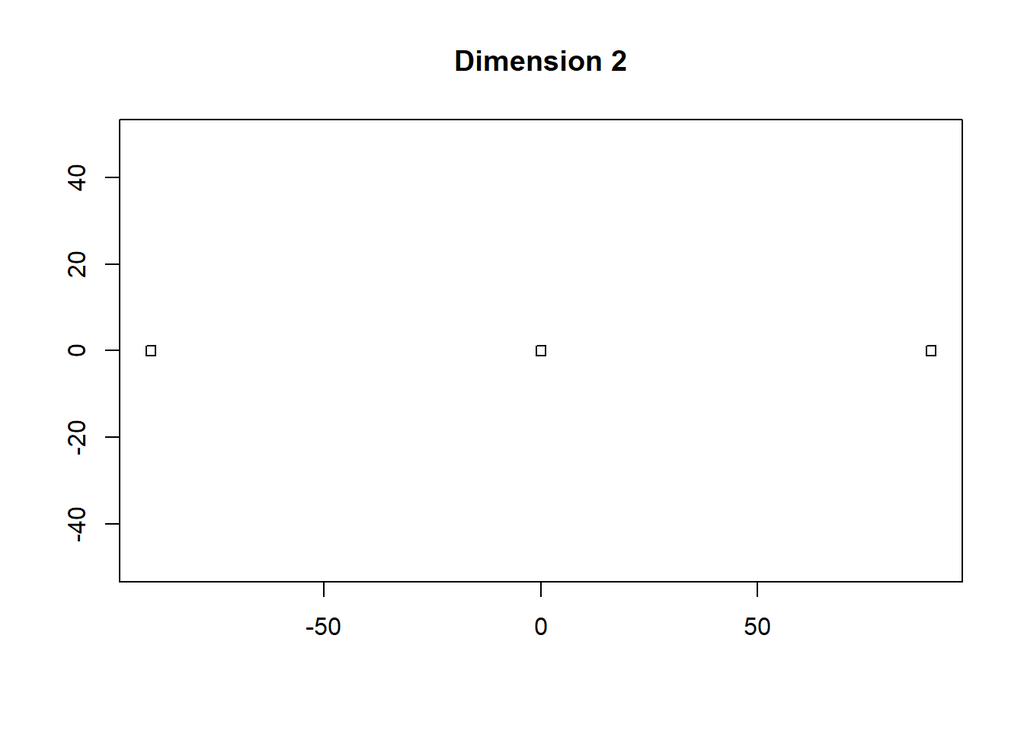

```r
ex1d2 <- cmdscale(ex1,k = 2)
plot(ex1d2[,1], ex1d2[,2], type = "p",pch = 22, xlab = "", ylab = "", asp = 1, axes = TRUE,  main = "Dimension 2")
```

Заметим, что объекты разместились на прямой. Вычислим расстояние между объектами результата

```r
dist(ex1d2)
```

```
##     1   2
## 2  90
## 3 180  90
```

Как мы видим расстояния между размещенными объектами совпадают с исходными Теперь проверим возможность размещения в одномерном пространстве и вычислим растояния между результатами размещения

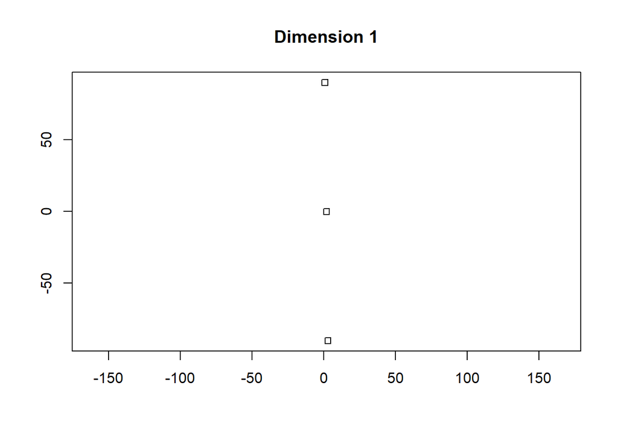

```r
ex1d1 <- cmdscale(ex1,k = 1)
matplot(ex1d1[,1], type = "p",pch = 22, xlab = "", ylab = "", asp = 1, axes = TRUE,  main = "Dimension 1")
```

```r
dist(ex1d1)
```

```
##     1   2
## 2  90
## 3 180  90
```

Расстояния между размещенными объектами также совпадают с исходными. Таким образом возможно точное размещение в одномерном пространстве

### Пример 2

Пусть теперь исходная матрица расстояний

```r
ex2 <- rbind(c(0,90,90),c(90,0,90),c(90,90,0))
ex2
```

```
##      [,1] [,2] [,3]
## [1,]    0   90   90
## [2,]   90    0   90
## [3,]   90   90    0
```

Попробуем провести многомерное шкалирование в 2-мерном пространстве и вычислим растояние между результатом

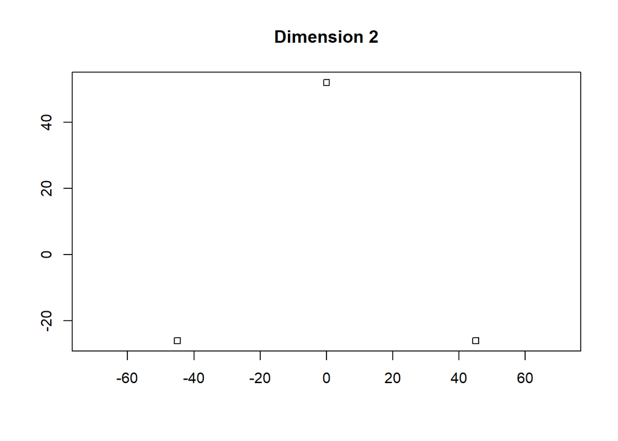

```r
ex2d2 <- cmdscale(ex2,k = 2)
plot(ex2d2[,1],ex2d2[,2], type = "p",pch = 22, xlab = "", ylab = "", asp = 1, axes = TRUE,  main = "Dimension 2")
```

```r
dist(ex2d2)
```

```
##    1  2
## 2 90
## 3 90 90
```

Возможно точное размещение, расстояния полностью сохранены. Теперь попробуем в одномерном пространстве

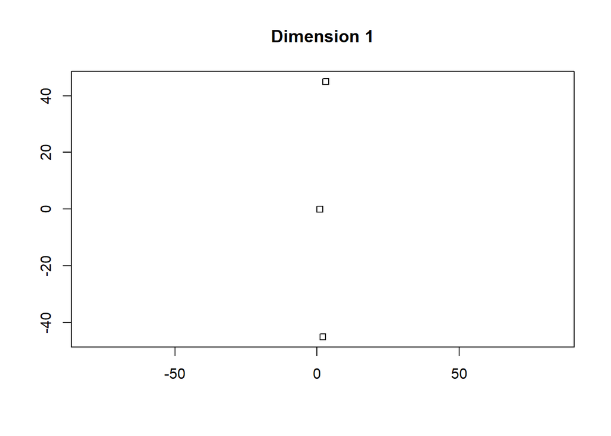

```r
ex2d1 <- cmdscale(ex2,k = 1)
matplot(ex2d1[,1], type = "p",pch = 22, xlab = "", ylab = "", asp = 1, axes = TRUE,  main = "Dimension 1")
```

```r
dist(ex2d1)
```

```
##    1  2
## 2 45
## 3 45 90
```

Расстояния между результати размещения кардинально отличаются от исходных.

### Пример 3

Пусть заданы расстояния между некоторыми городами западной Европы. И попробуем их разместить в 2-мерном пространстве.

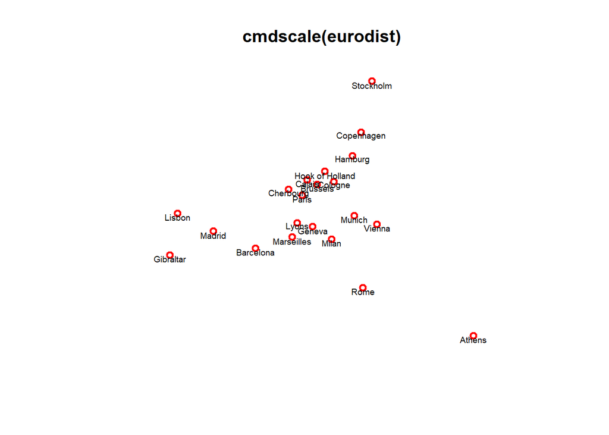

```r
require(graphics)
loc <- cmdscale(eurodist,k = 2)
x <- loc[, 1]
y <- -loc[, 2]
plot(x, y, type = "p", xlab = "", ylab = "", asp = 1, axes = FALSE,
     main = "cmdscale(eurodist)",col = "red",lwd = 2)
text(x, y-50, rownames(loc), cex = 0.6)
```

Результат очень похож на реальную географическую карту Европы. Что говорит об удачном размещении.

### Пример 4

Много говорилось особенно в отечественных СМИ о политизированности оценок жюри конкурса Евровидение-2016, в котором победила певица с Украины Джамала. Попробуем разместить матрицу расстояний, полученную из оценок жюри на плоскости.

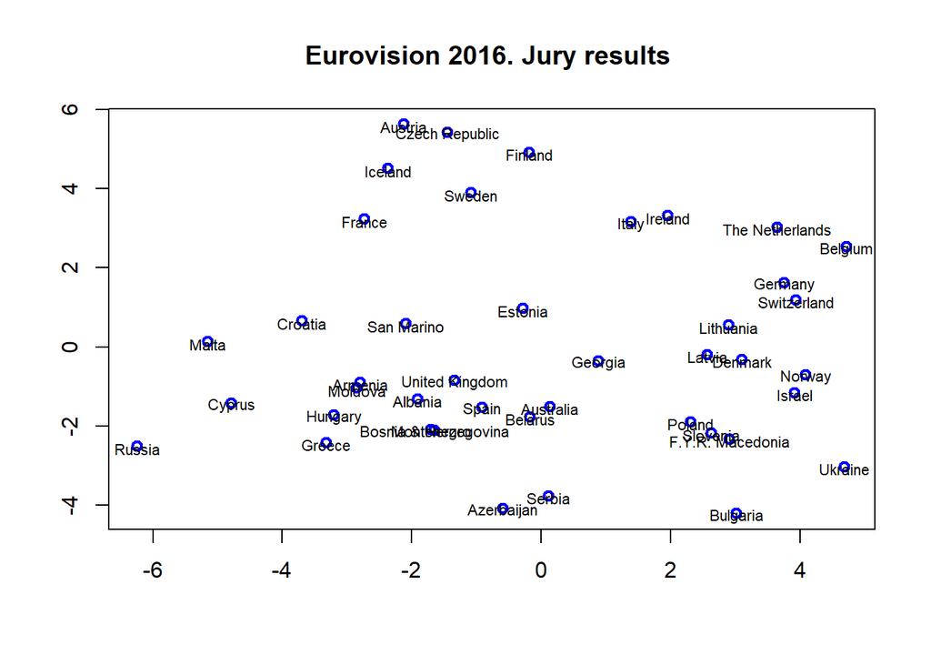

```r
Data <- read.csv("./juri.csv")
require(graphics)
row.names(Data) <- Data[, 1]
Data <- Data[, -1]
fit <- cmdscale(Data, eig = TRUE, k = 2)
x <- fit$points[, 1]
y <- fit$points[, 2]
plot(x, y, type = "p", xlab = "", ylab = "",
     main = "Eurovision 2016. Jury results ",col ="blue",lwd = 2)
text(x, y-0.05, rownames(Data), cex = 0.7)
```

Вот такая карта Европы от жюри получилась. А теперь посмотрим карту Европы от населения Европы

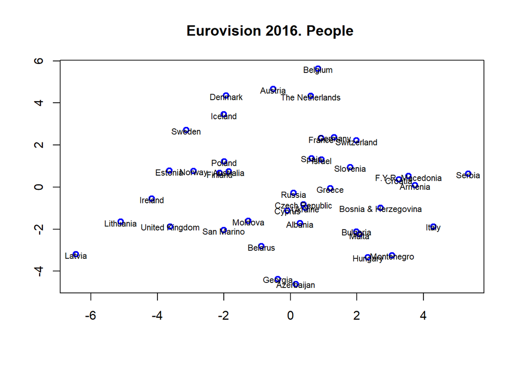

```r
DataPeople <- read.csv("./People.csv")
require(graphics)
row.names(DataPeople) <- DataPeople[, 1]
DataPeople <- DataPeople[, -1]
fitPeople <- cmdscale(DataPeople, eig = TRUE, k = 2)
x <- fitPeople$points[, 1]
y <- fitPeople$points[, 2]
plot(x, y, type = "p", xlab = "", ylab = "",
     main = "Eurovision 2016. People ",col ="blue",lwd = 2)
text(x, y-0.05, rownames(Data), cex = 0.7)
```

Ну что, статистика говорит, что народы России и Украины братские. В отличие от политизированного жюри.

Попробуем посмотреть на дендрограмму иерархической кластеризации методом Ward для данных жюри

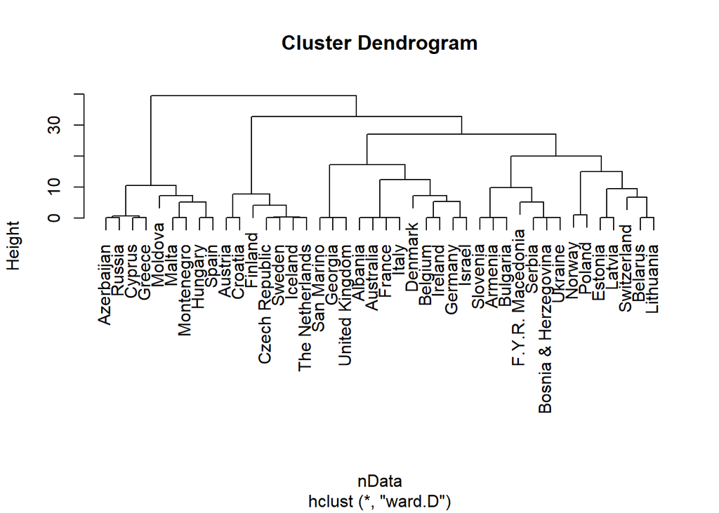

```r
Data <- read.csv("./juri.csv")
require(graphics)
row.names(Data) <- Data[, 1]
Data <- Data[, -1]
nData <- as.dist (Data)
hEuro <- hclust(nData,method = "ward.D")
plot(hEuro)
```

Тот же самый метод для народного голосования

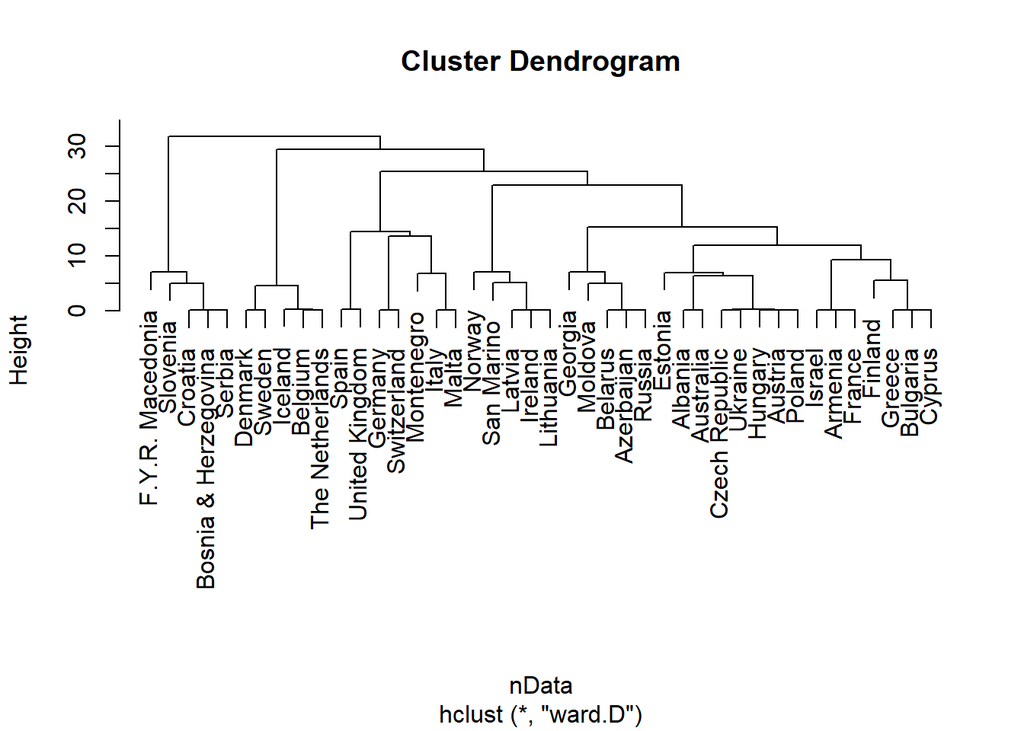

```r
Data <- read.csv("./people.csv")
require(graphics)
row.names(Data) <- Data[, 1]
Data <- Data[, -1]
nData <- as.dist (Data)
hEuro <- hclust(nData,method = "ward.D")
plot(hEuro)
```